# ASNU: Aggregated Social Network Unfolder

### Generating Realistic Synthetic Networks from Aggregate Demographic Data

**Kamiel Gulpen**  
PhD Research

## Outline

1. **Introduction** — Motivation, research question, classic models
2. **Data** — Dutch population statistics, interaction layers
3. **Framework** — Architecture, community assignment, edge creation, multiplex
4. **Experiments** — Community analysis, parameter sweep, contagion dynamics
5. **Comparison & Conclusion** — Related work, contributions, future work

# 1. Introduction

## Motivation

**The problem:**

- Agent-based models (ABMs) for epidemiology, policy analysis, and social simulation require **realistic contact networks**
- Individual-level interaction data is rarely available due to privacy and cost
- What *is* available: **aggregate demographic statistics** (census, surveys)

**The gap:**

- Classic network models (ER, BA, SBM) generate from abstract parameters
- Existing synthetic population tools often lack network generation or require geospatial data

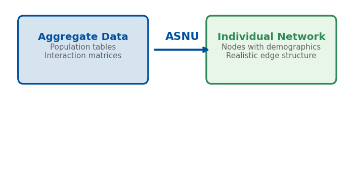

## Research Question

> **How can we *unfold* aggregated population-level interaction data into realistic individual-level social networks that preserve demographic structure and exhibit tunable topological properties?**

**Requirements:**

1. Preserve group-level interaction counts from input data
2. Support tunable network properties: preferential attachment, reciprocity, transitivity
3. Generate community structure consistent with demographic mixing patterns
4. Scale to large populations (millions of nodes)
5. Support multiplex (layered) networks: household, family, neighborhood, work/school

## Classic Models and Their Limitations

| **Property** | **Erdős–Rényi** | **Barabási–Albert** | **SBM** | **ASNU** |
| --- | --- | --- | --- | --- |
| Input | *n, p* | *n, m* | Block matrix | **Real data** |
| Degree distribution | Poisson | Power-law | Per-block | **Data-driven** |
| Communities | — | — | Yes | **Yes** |
| Directed edges | — | — | Optional | **Yes** |
| Reciprocity | — | — | — | **Tunable** |
| Transitivity | ≈ 0 | Low | Within-block | **Tunable** |
| Multiplex | — | — | — | **Yes** |
| Demographics | — | — | Block label | **Rich** |

Classic models ask: *"What does a network look like given abstract rules?"*  
ASNU asks: *"Given real population data, what could the actual network look like?"*

# 2. Data

## Data Sources: Dutch Population Statistics

### Population Data

Demographic group sizes from aggregated survey/census data.

| **Gender** | **Age** | **Ethnicity** | **Education** | **n** |
| --- | --- | --- | --- | --- |
| Female | [20,30) | Other | 1 | 3,870 |
| Female | [20,30) | Other | 2 | 15,730 |
| Male | [50,60) | Native | 1 | 4,911 |
| Male | [0,20) | Native | 3 | 32,450 |
| ... | ... | ... | ... | ... |

- **85 demographic groups**, ~**5.7 million** total population

### Demographic Characteristics

- **Gender** (2): Male, Female
- **Age** (5+): [0,20), [20,30), [30,40), [40,50), [50,60), 60+
- **Ethnicity** (3): Native, Moroccan, Other
- **Education** (3): Low, Medium, High

> ASNU accepts **any** set of categorical characteristics — the framework is not tied to specific demographic variables.

## Data Sources: Interaction Layers

**Four interaction layers** capture different social contexts:

| **Layer** | **Description** | **Group Pairs** | **Context** |
| --- | --- | --- | --- |
| `huishouden` | Household contacts | ~8,700 | Co-residence |
| `familie` | Family contacts | ~4,200 | Kinship ties |
| `buren` | Neighbor contacts | ~24,800 | Spatial proximity |
| `werkschool` | Work/school contacts | ~13,800 | Occupational |

Each layer is a matrix of **aggregate interaction counts** between source–destination group pairs:

| **Source** |  |  |  | **Destination** |  |  |  | **n** |
| --- | --- | --- | --- | --- | --- | --- | --- | --- |
| *gender* | *age* | *edu* | *ethn* | *gender* | *age* | *edu* | *ethn* |  |
| Male | [0,20) | 1 | Native | Male | [0,20) | 1 | Native | 14,580 |
| Male | [0,20) | 1 | Native | Male | [0,20) | 2 | Native | 360 |
| Female | [30,40) | 2 | Other | Male | [40,50) | 3 | Native | 1,245 |

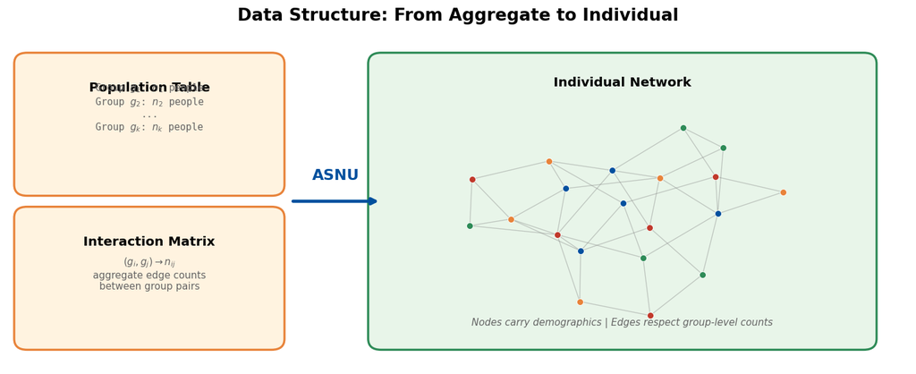

# 3. Framework

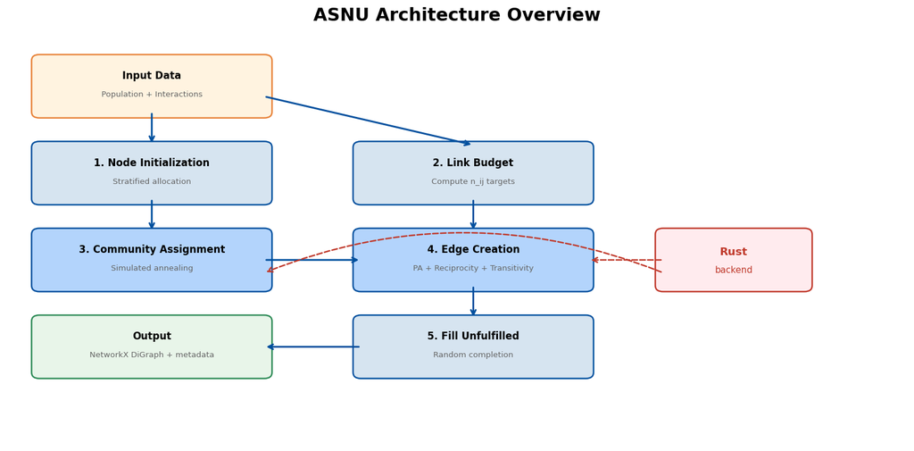

## Step 1: Node Initialization — Stratified Allocation

> **Goal:** Create $N' = \text{scale} \times N$ nodes preserving the demographic distribution of the original population.

**Stratified allocation algorithm:**

1. For each group $g_i$ with population $n_i$, compute target: $n'_i = \lfloor \text{scale} \times n_i \rfloor$
2. Distribute remainder $r = N' - \sum n'_i$ to groups with the largest fractional parts
3. Assign demographic attributes to each node

**Example** (scale = 0.01, $N = 5.7$M):

[output not shown]

**Agent-based assignment:** each node chooses a community to minimize distance from its *ideal link distribution*.

For node $v$ in group $g$, and community $c$:

$$d(v, c) = \sum_{g'} \left| P_{\text{ideal}}(g, g') - P_{\text{actual}}(c, g') \right|$$

**Simulated annealing schedule:**

- High temperature → stochastic exploration
- Low temperature → greedy exploitation
- Selection probability: $P(\text{select } c) \propto e^{-d(v,c) / T}$

**Community size distributions:** Natural | Uniform | Power-law

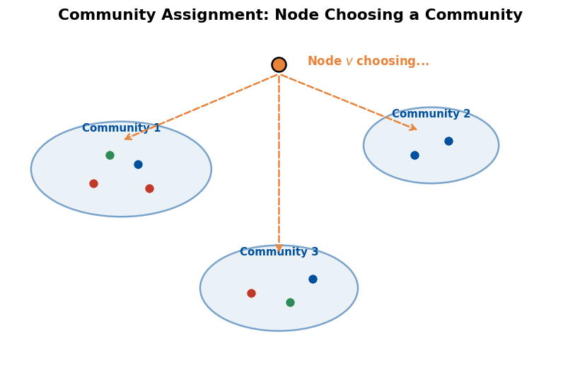

Three tunable mechanisms operate **simultaneously** during edge creation:

### Preferential Attachment

Popular nodes attract more edges.

- Popularity pool: subset of destination nodes
- Smaller pool → stronger PA
- Scope: *local* (within community) or *global*

### Reciprocity

Mutual connections.

- $P(\text{add } v \rightarrow u \mid u \rightarrow v) = r$
- Parameter $r \in [0,1]$
- Respects link budget constraints

### Transitivity

Friend-of-a-friend closure.

- $P(\text{add } u \rightarrow w \mid u \rightarrow v, v \rightarrow w) = t$
- Creates clustering coefficient
- Parameter $t \in [0,1]$

> **Bridge Probability:** With probability $b$, an edge targets a **neighboring community** instead of the node's own community.

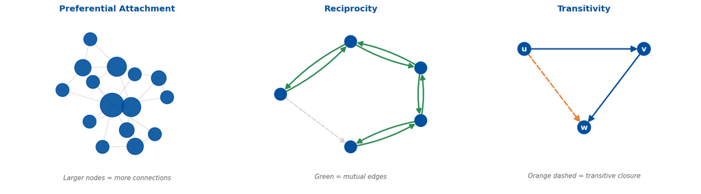

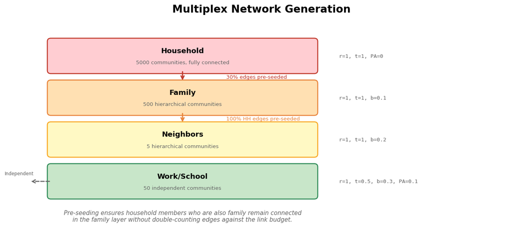

## Performance: Rust Backend

Critical computation is offloaded to **Rust** (via PyO3) with automatic Python fallback:

| **Operation** | **Rust Function** | **Optimization** |
| --- | --- | --- |
| Community assignment | `process_nodes()` | Vectorized distance computation |
| Capacity assignment | `process_nodes_capacity()` | Flat 2D arrays, cache-friendly |
| Edge creation | `run_edge_creation()` | Batch community sampling |

**Key design decisions:**

- Rust provides **10–100x speedup** over pure Python
- All Rust functions have equivalent Python fallbacks for portability
- Enables generation at 1% scale (~57,000 nodes) in reasonable time, with path to full-scale

# 4. Experiments

## Experiment 1: Community Structure Analysis

**Metrics computed:**

- Community size distribution (mean, std, CV)
- Unique groups per community
- **Shannon entropy:** $H = -\sum_g p_g \log p_g$
- **Pielou's evenness:** $J = H / H_{\max}$
- **Simpson's diversity:** $D = 1 - \sum_g p_g^2$

**Key findings:**

- Communities are heterogeneous in size (natural distribution)
- Shannon entropy range: 0.0–1.0, indicating variable group diversity within communities
- Pielou's evenness: 0.3–0.9, most communities show moderate diversity
- Larger communities tend toward higher diversity (size–entropy correlation)

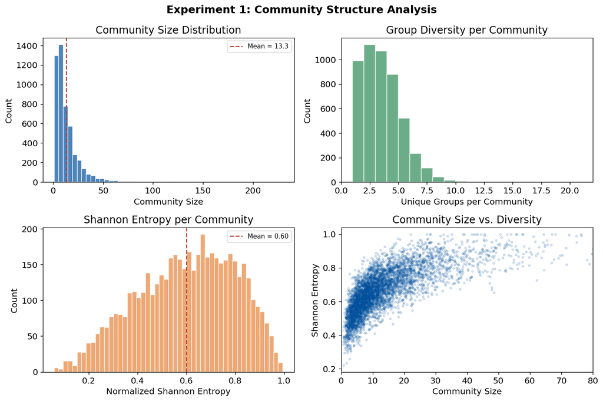

## Experiment 2: Parameter Grid Search

**Setup:** Systematic sweep over community count and preferential attachment strength.

**Parameters varied:**

- **Communities:** 10 values
- **Preferential attachment:** 10 values in [0, 1]
- All 4 interaction layers
- All characteristic combinations (2^4 = 16)

**Metrics recorded per network:**

- Number of nodes and edges
- Reciprocity
- Average clustering coefficient
- Degree distribution (mean, std, skewness)

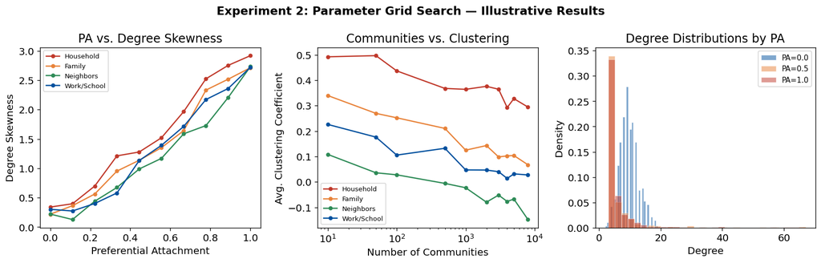

## Experiment 3: Contagion Dynamics on Generated Networks

**Goal:** Validate that network topology affects diffusion dynamics as expected.

**Three contagion models tested:**

1. **Simple contagion** (SI model): $P(\text{infect}) = p$ per contact — Parameters: $p=0.01$, $I_0=800$
2. **Complex contagion** (threshold): Adopt if fraction of infected neighbors $\geq \theta$ — Parameters: $\theta=0.25$
3. **Hybrid contagion**: Heterogeneous thresholds — vulnerable vs. normal nodes

50 simulations per configuration, vectorized via sparse matrices.

**Results:**

- **Simple contagion:** Minimal topology dependence — spreads broadly regardless of structure
- **Complex contagion:** *Highly sensitive* to network topology
  - Tightly clustered networks → slower spread
  - Scale-free-like structure → faster spread via hubs
- **Variance** in adoption rates correlates with group concentration (Herfindahl index)

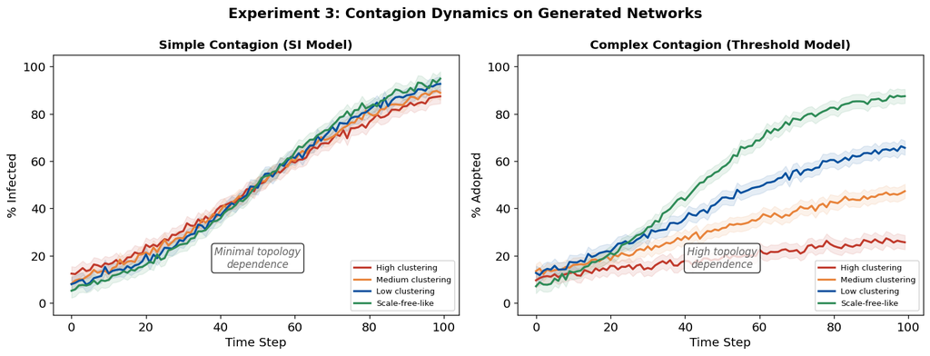

## Experiment 4: Contagion Parameter Sweep

**Setup:** Threshold sweep ($\theta = 0.05$ to $0.30$) across all network configurations from the grid search.

> **Key finding:** The **variance** in complex contagion outcomes across network realizations is highest for intermediate parameter values — confirming that ASNU-generated networks produce meaningfully different topologies that affect dynamic processes.

**Implications:**

- Network structure *matters* for policy-relevant questions (e.g., vaccination strategies)
- ASNU's tunable parameters create a rich space of topologies
- The choice of PA, community count, and bridge probability produces measurably different diffusion outcomes

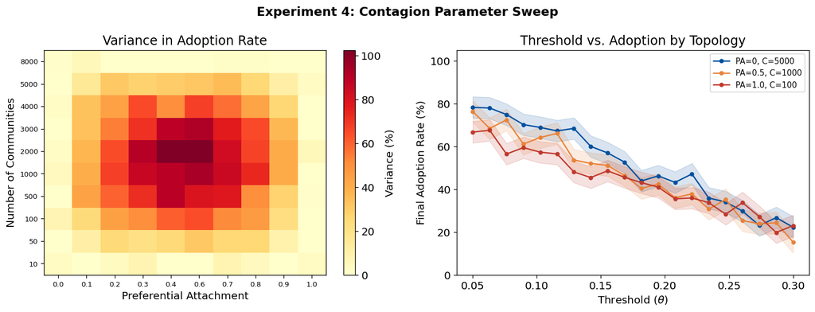

# 5. Comparison & Conclusion

## Comparison with Related Frameworks

|  | **Simdemics** | **June** | **Jiang+** | **RTI** | **FRED** | **ASNU** |
| --- | --- | --- | --- | --- | --- | --- |
| Demographic population | Yes | Yes | Yes | Yes | Yes | **Yes** |
| Network generation | Yes | Yes | Yes | No | Internal | **Yes** |
| Standalone network tool | No | No | Partial | — | No | **Yes** |
| Requires geospatial data | Yes | Yes | Yes | Yes | Yes | **No** |
| Multiplex layers | Yes | Yes | Yes | — | Yes | **Yes** |
| Tunable PA / reciprocity | No | No | No | — | No | **Yes** |
| Explicit communities | Location | Location | Location | — | Location | **Agent-based** |
| Input flexibility | US-specific | UK-specific | US Census | US Census | US Census | **Any CSV** |

**ASNU fills the gap** between:

- Tools that generate *populations without networks* (RTI SynthPop)
- Tools that generate *networks inside simulators* (FRED, June)

→ A **standalone**, **input-flexible**, **tunable** network generator from aggregate data.

## Summary & Contributions

> **ASNU: Aggregated Social Network Unfolder** — A framework for generating realistic synthetic networks from aggregate demographic and interaction data.

### Key contributions:

1. **Top-down approach:** Unfolds population-level statistics into individual networks (vs. bottom-up rule-based generation)
2. **Agent-based community assignment:** Simulated annealing optimizes community composition to match ideal mixing patterns
3. **Simultaneously tunable mechanisms:** Preferential attachment, reciprocity, transitivity, and bridge probability operate independently
4. **Hierarchical multiplex support:** Layers build upon each other with edge pre-seeding
5. **Input agnosticism:** Works with any categorical demographic data — not tied to a specific country or data source
6. **Performance:** Rust backend enables large-scale generation with Python fallback for portability

**Validated through:** community structure analysis, parameter sensitivity studies, and contagion experiments demonstrating that generated network topology meaningfully affects diffusion dynamics.

## Future Work

- **Weighted edges:** Extend edge creation to support interaction frequency/strength
- **Temporal dynamics:** Generate evolving networks with time-varying interaction patterns
- **Validation against real networks:** Compare generated topological properties with observed contact networks
- **Full-scale generation:** Optimize Rust backend for complete population (~5.7M nodes)
- **Additional contagion models:** SIR/SEIR dynamics, information diffusion, opinion dynamics
- **Sensitivity analysis:** Systematic study of how input data uncertainty propagates to network properties